# Portfolio 5 Part 2: Kernels

Justine Lang

2024-01-30

```r
knitr::opts_chunk$set(echo = TRUE, warning = FALSE, message = FALSE, results = FALSE)

library(tidyverse)
library(here)
library(janitor)
library(adehabitatHR)
library(sp)
```

Creating kernels involves the same initial steps as creating MCPs. Like before, we’ll start with 6 elk from the National Elk Refuge and create our SpatialPointsDataFrame.

```r
### Let's start as we did before: read in the csv and filter to 6 elk from the NER

elk <- read_csv(here("Habitat_Portfolio", "elk_collar.csv"))

elk <- elk %>%
  mutate_at("id", as.character)

elk_ner <- elk %>%
  filter(feedground == "National_Elk_Refuge") %>%
  filter(id %in% c("631", "632", "633", "634", "635", "636"))
```

```r
### Same process creating your SpatialPointsDataFrame

elk_ner <- elk_ner[!is.na(elk_ner$x) & !is.na(elk_ner$y),]

elk.sp <- elk_ner[, c("id", "x", "y")]

coordinates(elk.sp) <- c("x", "y")

proj4string(elk.sp) <- CRS("+proj=utm +zone=12 +datum=WGS84 +units=m +no_defs")
```

Use the `kernelUD` function to create our kernels. There are multiple approaches to choosing h. The default for this function is “reference bandwidth,” which works relatively well with most telemetry data. The downside is that it tends towards “oversmoothing,” meaning it often estimates a larger home range than other methods of choosing h.

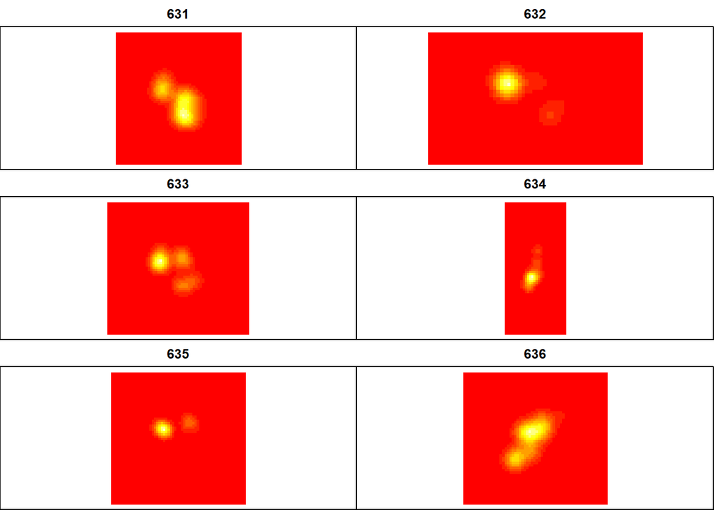

```r
kernel.ref <- kernelUD(elk.sp, h = "href")  # href = the reference bandwidth
image(kernel.ref) # plot
```

```r
kernel.ref[[1]]@h # The smoothing factor is stored for each animal in the "h" slot
```

A second common method of choosing h is “least squares cross validation,” which minimizes the error by comparing the prediction from all data points to the data minus each point. It works especially well if you have GPS collar data with frequently collected locations. However, it may not be as appropriate for infrequent relocation data (every few days or less).

```r
kernel.lscv <- kernelUD(elk.sp, h = "LSCV") ### Least squares cross validation
```

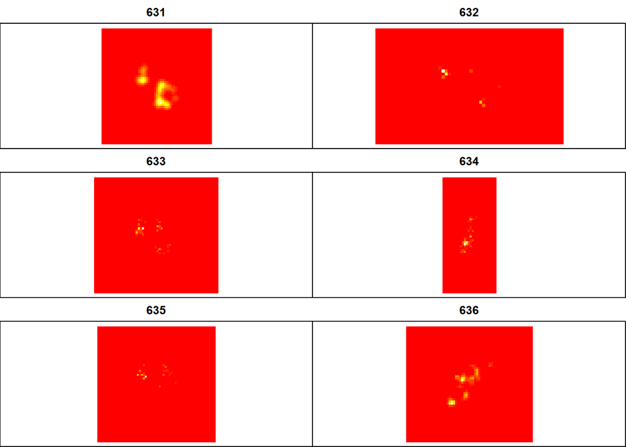

```r
image(kernel.lscv) ### plot
```

You can visually inspect a plot of the LSCV kernels to see how well this method might fit your data. Ideally, you want to look for a dip in the CV value and the h value that corresponds to the minimum CV is used. If there is no minimum (no dip), this can sometimes lead to errors in plotting the kernels. If an animal’s habitat is fragmented or if the relocation data is otherwise infrequent, then the LSCV method may not be as appropriate for the data.

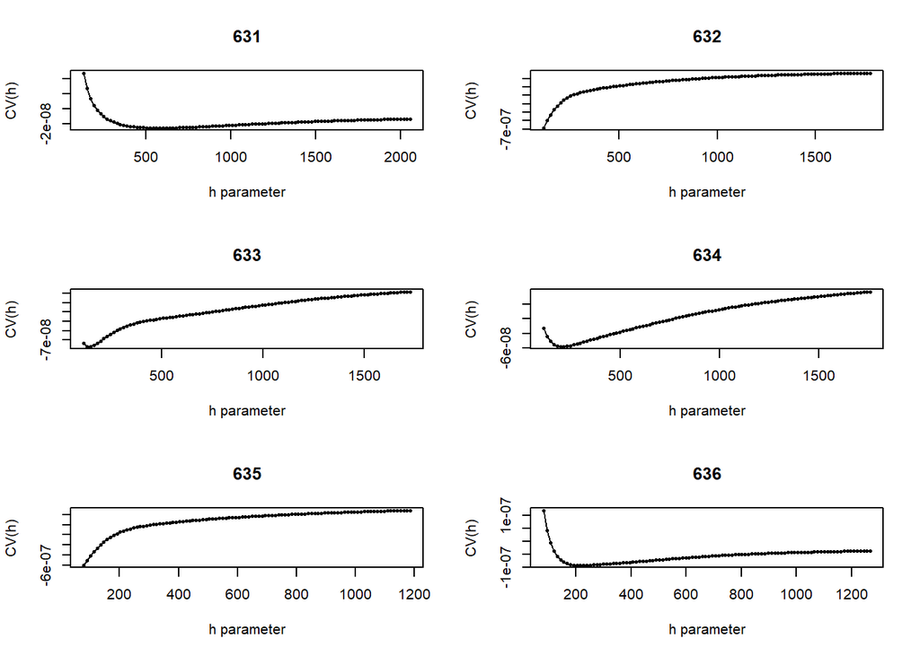

```r
plotLSCV(kernel.lscv) ### Look for a dip
```

Use the `getverticeshr` function to measure home ranges by setting a percentage of the distribution within the contour lines. A 95% distribution within the contour is the default, but it can be manually changed, along with the default units (hectares are the default output). Like with the MCPs, knowing a species’ biology is important in selecting the percentage. A 95% distribution may be ideal for many reptiles and amphibians but not necessarily for other types of animals.

```r
elk.kernel.poly <- getverticeshr(kernel.ref, percent = 95)
print(elk.kernel.poly)  # returns the area of each polygon
```

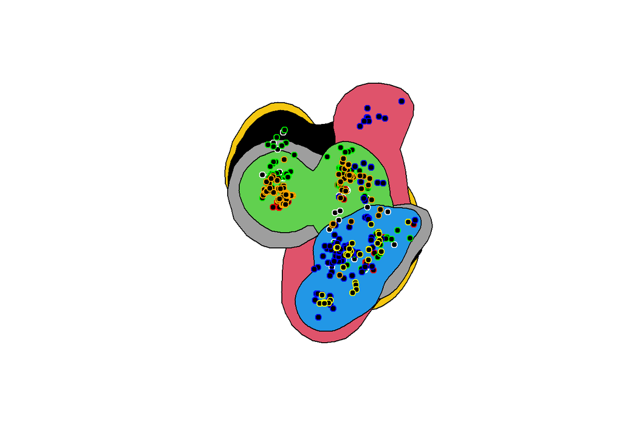

```r
color <- rep("white", nrow(elk.sp@data))
  color[(elk.sp@data$id == "632")] <- "red"
  color[(elk.sp@data$id == "633")] <- "green"
  color[(elk.sp@data$id == "634")] <- "blue"
  color[(elk.sp@data$id == "635")] <- "orange"
  color[(elk.sp@data$id == "636")] <- "yellow"
plot(elk.kernel.poly, col = elk.kernel.poly@data$id)
  plot(elk.sp, add = TRUE, col = color, pch = 21)
```

### Porfolio Assignment Questions Part 2:

2. Compare the plots from the 2 methods of choosing “h”. Which is more suitable for the elk?

Each elk herd in the GYE is bizarrely unique, and their movement often depends on the feedground they are associated with if they are a fed herd. Inspecting the graphs and data is the best way to tell which method best suits the individual elk or herds you’re interested in. For these six elk, several do not have the “dip” in the LSCV graphs, which suggests that the reference bandwidth method might be better in this instance, but that might not always be the case.

3. Explore how changing the feedground or elk individuals changes the home-range. What is one thing that stands out to you that is notable/different?

Most of the elk in the same herd have the same home range and migration patterns, which make sense. On the NER in particular, the elk stay clustered together throughout much of the feeding season. Elk from other smaller feedgrounds, however, don’t necessarily maintain the same high density throughout their home range.

**OPTIONAL:** Like with the MCPs, you can repeat this process with the fed elk herds instead of the individual animals, though your computer may get a bit of a workout attempting to create kernels for more than one or two herds at a time, especially through the LSCV method. For the sake of time, we’ll skip this today, but if you happen to have time to kill, feel free to go for it!